# Dates and Times

MPA 634: Data Science for Managers

10/28/2019

## 16.2 Creating date/times

Three types of date/time data

- A date, which tibbles print as “date”
- A time, which tibbles print as “time”
- A date-time, which tibbles as “dttm” and else where in R as POSIXct

Functions that give the current day and the current date-time are:

```r
today()
```

```
## [1] "2019-10-28"
```

```r
now()
```

```
## [1] "2019-10-28 09:13:18 MDT"
```

Creation of date/time:

- From a string
- From individual date-time components
- From an existing date/time object

### 16.2.1 From Strings

```r
ymd("2019-02-28")
```

```
## [1] "2019-02-28"
```

```r
ymd(20190218)
```

```
## [1] "2019-02-18"
```

```r
mdy("February 28, 2019")
```

```
## [1] "2019-02-28"
```

```r
dmy("28-Feb-2019")
```

```
## [1] "2019-02-28"
```

Create date-time by adding and underscore and “h”, “m”, and “s”.

```r
ymd_hms("2019-02-28 13:12:30", tz = "MST")
```

```
## [1] "2019-02-28 13:12:30 MST"
```

```r
mdy_hm("2-28-2019 13:13", tz = "MST")
```

```
## [1] "2019-02-28 13:13:00 MST"
```

### 16.2.2 From individual components

```r
flights %>%
  select(year, month, day, hour, minute) %>%
  mutate(depature = make_datetime(year, month, day, hour, minute))
```

```
## # A tibble: 336,776 x 6
##     year month   day  hour minute depature
##    <int> <int> <int> <dbl>  <dbl> <dttm>
##  1  2013     1     1     5     15 2013-01-01 05:15:00
##  2  2013     1     1     5     29 2013-01-01 05:29:00
##  3  2013     1     1     5     40 2013-01-01 05:40:00
##  4  2013     1     1     5     45 2013-01-01 05:45:00
##  5  2013     1     1     6      0 2013-01-01 06:00:00
##  6  2013     1     1     5     58 2013-01-01 05:58:00
##  7  2013     1     1     6      0 2013-01-01 06:00:00
##  8  2013     1     1     6      0 2013-01-01 06:00:00
##  9  2013     1     1     6      0 2013-01-01 06:00:00
## 10  2013     1     1     6      0 2013-01-01 06:00:00
## # ... with 336,766 more rows
```

As we have done previously, we need to convert dep_time, sched_dep_time, arr_time, and sched_arr_time into time formats. Since we will do this repeatedly, we write a function.

```r
make_datetime_100 <- function(year, month, day, time){
  make_datetime(year, month, day, time %/% 100, time %% 100)
}

flights_dt <- flights %>%
  filter(!is.na(dep_time), !is.na(arr_time)) %>%
  mutate(
    dep_time = make_datetime_100(year, month, day, dep_time),
    arr_time = make_datetime_100(year, month, day, arr_time),
    sched_dep_time = make_datetime_100(year, month, day, sched_dep_time),
    sched_arr_time = make_datetime_100(year, month, day, sched_arr_time)
  ) %>%
  select(origin, dest, ends_with("delay"), ends_with("time"))

flights_dt %>% print()
```

```
## # A tibble: 328,063 x 9
##    origin dest  dep_delay arr_delay dep_time            sched_dep_time
##    <chr>  <chr>     <dbl>     <dbl> <dttm>              <dttm>
##  1 EWR    IAH           2        11 2013-01-01 05:17:00 2013-01-01 05:15:00
##  2 LGA    IAH           4        20 2013-01-01 05:33:00 2013-01-01 05:29:00
##  3 JFK    MIA           2        33 2013-01-01 05:42:00 2013-01-01 05:40:00
##  4 JFK    BQN          -1       -18 2013-01-01 05:44:00 2013-01-01 05:45:00
##  5 LGA    ATL          -6       -25 2013-01-01 05:54:00 2013-01-01 06:00:00
##  6 EWR    ORD          -4        12 2013-01-01 05:54:00 2013-01-01 05:58:00
##  7 EWR    FLL          -5        19 2013-01-01 05:55:00 2013-01-01 06:00:00
##  8 LGA    IAD          -3       -14 2013-01-01 05:57:00 2013-01-01 06:00:00
##  9 JFK    MCO          -3        -8 2013-01-01 05:57:00 2013-01-01 06:00:00
## 10 LGA    ORD          -2         8 2013-01-01 05:58:00 2013-01-01 06:00:00
## # ... with 328,053 more rows, and 3 more variables: arr_time <dttm>,
## #   sched_arr_time <dttm>, air_time <dbl>
```

### Departures by day for the year. The number of seconds in a day is 24 * 60 * 60 = 86400 seconds.

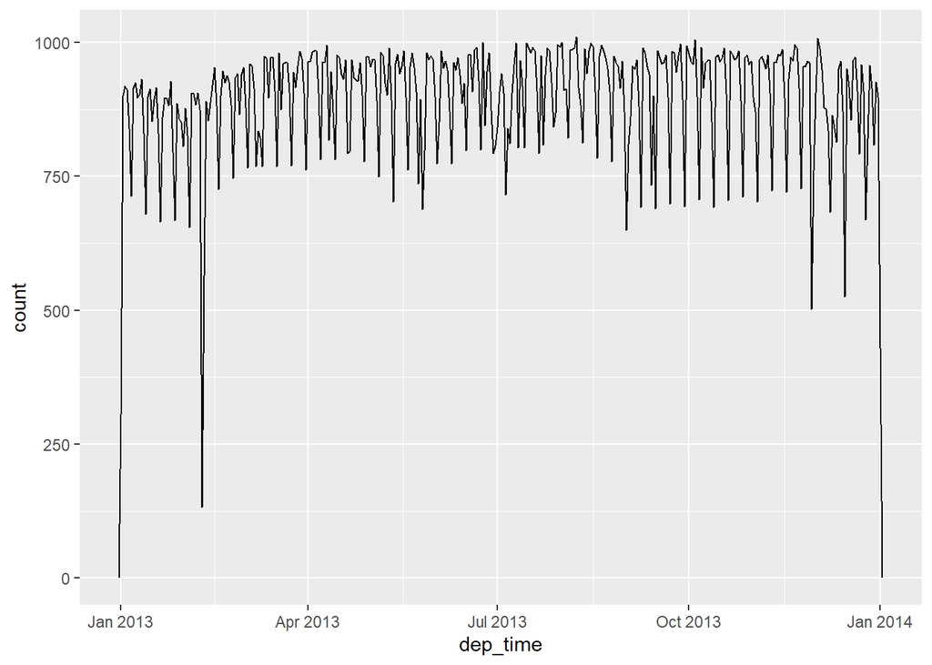

```r
flights_dt %>%
  ggplot(aes(dep_time)) +
  geom_freqpoly(binwidth = 86400)
```

### Departures in a single day. The number of seconds in 10 minutes is 10 * 60 = 600 seconds. Choose January 1, 2013 as the day

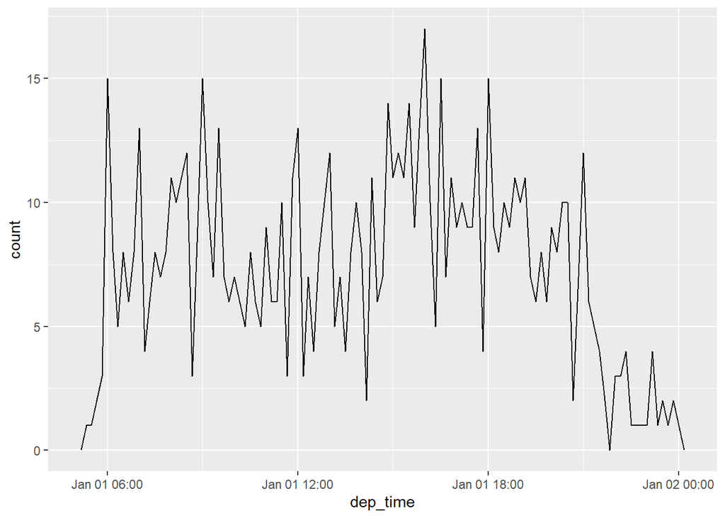

```r
flights_dt %>%
  filter(dep_time < ymd(20130102)) %>%
  ggplot(aes(dep_time)) +
  geom_freqpoly(binwidth = 600)
```

### 16.2.3 From other types

```r
today() %>% as_datetime()
```

```
## [1] "2019-10-28 UTC"
```

```r
now() %>% as_date()
```

```
## [1] "2019-10-28"
```

```r
as_datetime(60 * 60 * 10) # Should give us 10 o'clock
```

```
## [1] "1970-01-01 10:00:00 UTC"
```

```r
as_date(365 * 10 + 2)
```

```
## [1] "1980-01-01"
```

## 16.3 Date-time components

### 16.3.1 Getting components

```r
datetime <- ymd_hms("2019-03-04 12:15:30")

datetime %>% year()
```

```
## [1] 2019
```

```r
datetime %>% month()
```

```
## [1] 3
```

```r
datetime %>% mday()
```

```
## [1] 4
```

```r
datetime %>% yday()
```

```
## [1] 63
```

```r
datetime %>% wday()
```

```
## [1] 2
```

```r
datetime %>% month(label = TRUE)
```

```
## [1] Mar
## 12 Levels: Jan < Feb < Mar < Apr < May < Jun < Jul < Aug < Sep < ... < Dec
```

```r
datetime %>% wday(label = TRUE, abbr = FALSE)
```

```
## [1] Monday
## 7 Levels: Sunday < Monday < Tuesday < Wednesday < Thursday < ... < Saturday
```

Let’s calculate and graph the number of flights that depart on each day of the week.

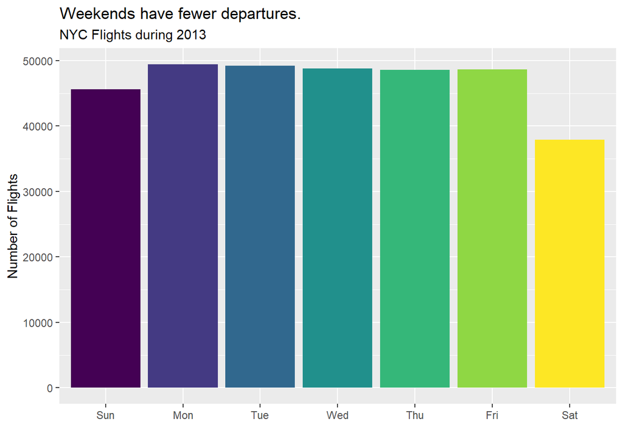

```r
flights_dt %>%
  mutate(weekday = wday(sched_dep_time, label = TRUE)) %>%
  ggplot(aes(x = weekday, fill = weekday)) +
  geom_bar(show.legend = FALSE) +
  labs(
    title = "Weekends have fewer departures.",
    subtitle = "NYC Flights during 2013",
    x = "",
    y = "Number of Flights"
  )
```

There is an interesting pattern for the average delay of departures during the hour. This is a graph of each minute in the hour of departure times and the average departure delay.

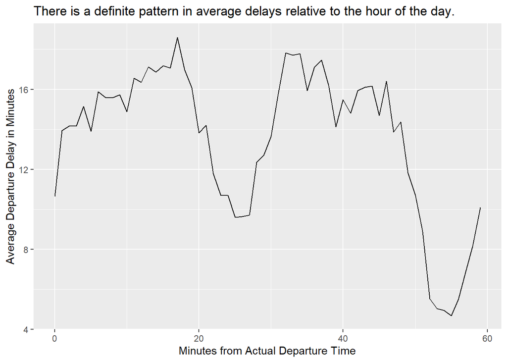

```r
flights_dt %>%
  mutate(minute = minute(dep_time)) %>%
  group_by(minute) %>%
  summarise(
    average_delay = mean(dep_delay, na.rm = TRUE)
  ) %>%
  ggplot(aes(minute, average_delay)) +
  geom_line() +
  labs(
    title = "There is a definite pattern in average delays relative to the hour of the day.",
    x = "Minutes from Actual Departure Time",
    y = "Average Departure Delay in Minutes"
  )
```

The pattern doesn’t seem to exist when we look at the schedule departures.

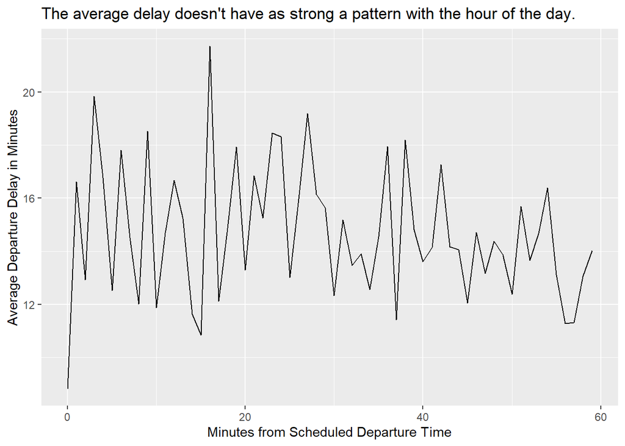

```r
flights_dt %>%
  mutate(minute = minute(sched_dep_time)) %>%
  group_by(minute) %>%
  summarise(
    average_delay = mean(dep_delay, na.rm = TRUE)
  ) %>%
  ggplot(aes(minute, average_delay)) +
  geom_line() +
  labs(
    title = "The average delay doesn't have as strong a pattern with the hour of the day.",
    x = "Minutes from Scheduled Departure Time",
    y = "Average Departure Delay in Minutes"
  )
```

The number of flights schedule for each minute of the hour does generate an interesting pattern.

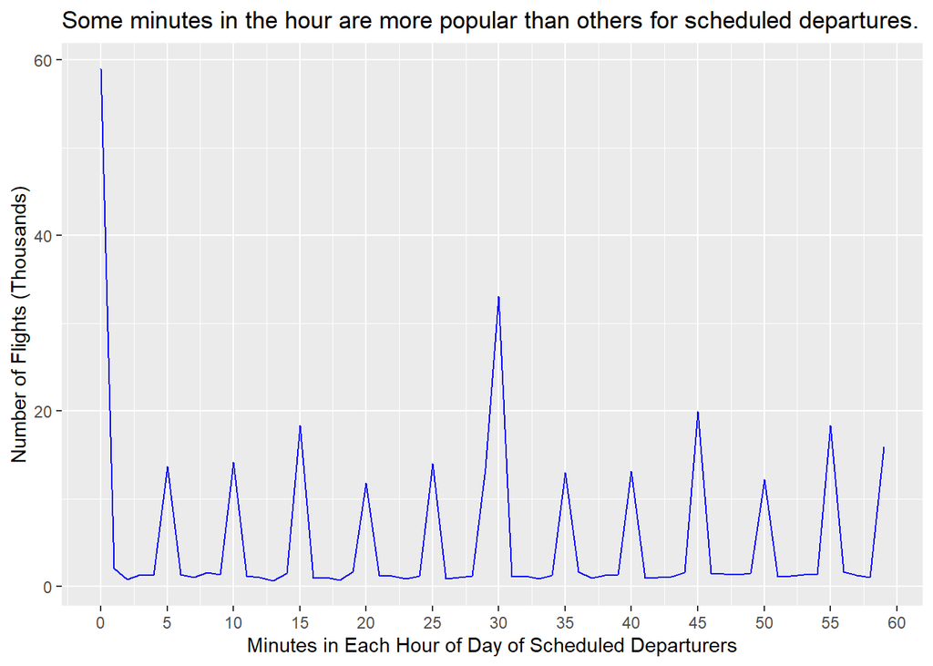

```r
flights_dt %>%
  mutate(minute = minute(sched_dep_time)) %>%
  group_by(minute) %>%
  summarise(
    number_of_flights = n()
  ) %>%
  ggplot(aes(minute, number_of_flights / 1000)) +
  geom_line(color = "blue") +
  labs(
    title = "Some minutes in the hour are more popular than others for scheduled departures.",
    x = "Minutes in Each Hour of Day of Scheduled Departurers",
    y = "Number of Flights (Thousands)"
  ) +
  scale_x_continuous(breaks = seq(0, 60, 5), labels = seq(0, 60, 5))
```

16.3.2 Rounding

Rounding can give us the number of flights in a week.

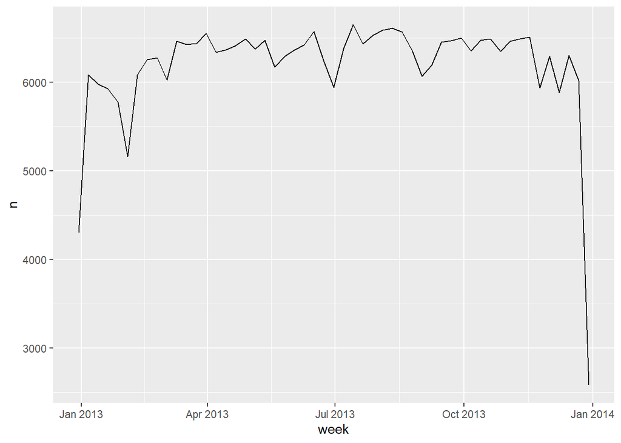

```r
flights_dt %>%
  mutate(
    week = floor_date(dep_time, "week")
  ) %>%
  count(week) %>%
  ggplot(aes(week, n)) +
  geom_line()
```

16.3.3 Setting components using the accessor functions

```r
(datetime <- ymd_hms("2019-03-04 12:15:00"))
```

```
## [1] "2019-03-04 12:15:00 UTC"
```

```r
(year(datetime) <- 2020)
```

```
## [1] 2020
```

```r
(month(datetime) <- 01)
```

```
## [1] 1
```

```r
(hour(datetime) <- hour(datetime) + 1)
```

```
## [1] 13
```

```r
(datetime <- update(datetime, year = 2020, month = 2, mday = 2, hour = 2))
```

```
## [1] "2020-02-02 02:15:00 UTC"
```

When values are too large then they roll over.

```r
ymd("2019-02-01") %>%
  update(mday = 31)
```

```
## [1] "2019-03-03"
```

```r
ymd("2019-02-01") %>%
  update(hours = 400)
```

```
## [1] "2019-02-17 16:00:00 UTC"
```

Use update to show the distribution of fights across the course of the day for every day of the year.

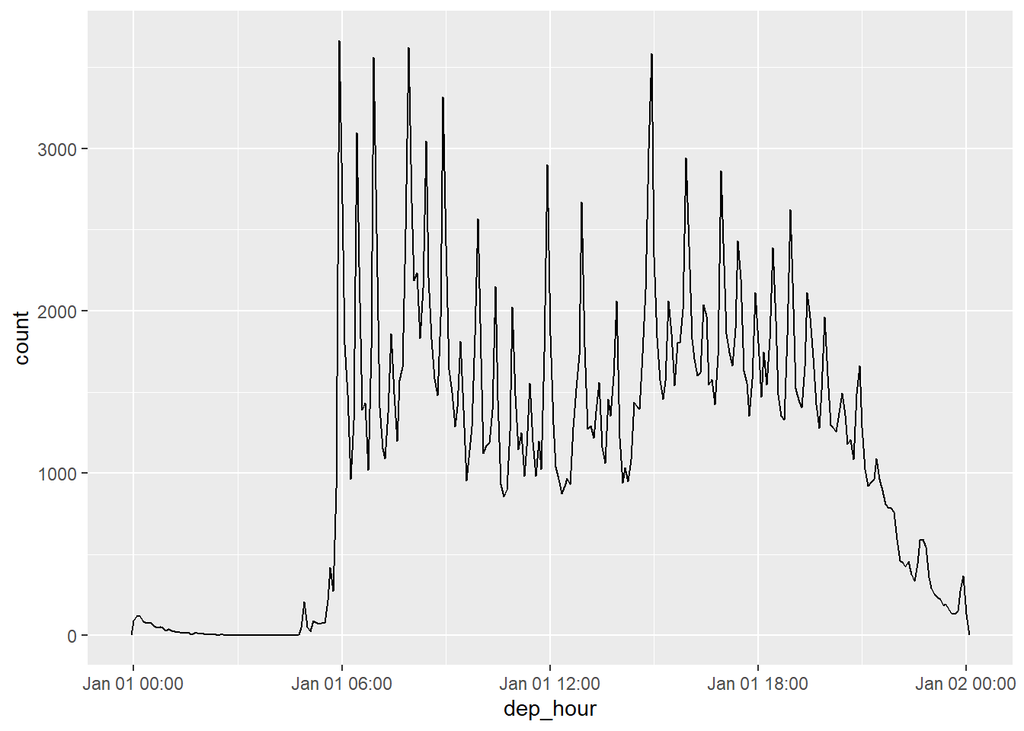

```r
flights_dt %>%
  mutate(dep_hour = update(dep_time, yday = 1)) %>%
  ggplot(aes(dep_hour)) +
  geom_freqpoly(binwidth = 300)
```